# Predicting Advertising Spend: From Poisson to Negative Binomial Regression

Poisson Regression with Overdispersion Correction via Negative Binomial

Analysis Report

2026-04-26

# 1 Introduction

This report models **local advertising spend** across 400 retail carseat locations using data from the `Carseats` dataset in the `ISLR` package. The analysis follows a two-stage approach:

1. We first fit a **Poisson regression model**, which is the natural starting point for count data.
2. We then diagnose the Poisson model and find significant **overdispersion** (variance far exceeding the mean), which violates a core Poisson assumption and inflates the apparent significance of predictors.
3. We address this by refitting using a **Negative Binomial regression model**, which relaxes the mean-variance equality constraint and produces more reliable standard errors and inference.

**Response variable:** `Advertising`, the local advertising budget (in thousands of dollars) at each store location.

**Predictors selected:** `Sales`, `Income`, `Price`, and `US`, chosen through correlation analysis and ANOVA testing (detailed in Section 4).

# 2 Setup

```r
library(ISLR)
library(tidymodels)
library(tidyverse)
library(GGally)
library(car)
library(broom)
library(gridExtra)
library(poissonreg)
library(MASS)
```

```r
data(Carseats)
glimpse(Carseats)
```

```
## Rows: 400
## Columns: 11
## $ Sales       <dbl> 9.50, 11.22, 10.06, 7.40, 4.15, 10.81, 6.63, 11.85, 6.54, …
## $ CompPrice   <dbl> 138, 111, 113, 117, 141, 124, 115, 136, 132, 132, 121, 117…
## $ Income      <dbl> 73, 48, 35, 100, 64, 113, 105, 81, 110, 113, 78, 94, 35, 2…
## $ Advertising <dbl> 11, 16, 10, 4, 3, 13, 0, 15, 0, 0, 9, 4, 2, 11, 11, 5, 0, …
## $ Population  <dbl> 276, 260, 269, 466, 340, 501, 45, 425, 108, 131, 150, 503,…
## $ Price       <dbl> 120, 83, 80, 97, 128, 72, 108, 120, 124, 124, 100, 94, 136…
## $ ShelveLoc   <fct> Bad, Good, Medium, Medium, Bad, Bad, Medium, Good, Medium,…
## $ Age         <dbl> 42, 65, 59, 55, 38, 78, 71, 67, 76, 76, 26, 50, 62, 53, 52…
## $ Education   <dbl> 17, 10, 12, 14, 13, 16, 15, 10, 10, 17, 10, 13, 18, 18, 18…
## $ Urban       <fct> Yes, Yes, Yes, Yes, Yes, No, Yes, Yes, No, No, No, Yes, Ye…
## $ US          <fct> Yes, Yes, Yes, Yes, No, Yes, No, Yes, No, Yes, Yes, Yes, N…
```

```r
summary(Carseats)
```

```
##      Sales          CompPrice       Income        Advertising
##  Min.   : 0.000   Min.   : 77   Min.   : 21.00   Min.   : 0.000
##  1st Qu.: 5.390   1st Qu.:115   1st Qu.: 42.75   1st Qu.: 0.000
##  Median : 7.490   Median :125   Median : 69.00   Median : 5.000
##  Mean   : 7.496   Mean   :125   Mean   : 68.66   Mean   : 6.635
##  3rd Qu.: 9.320   3rd Qu.:135   3rd Qu.: 91.00   3rd Qu.:12.000
##  Max.   :16.270   Max.   :175   Max.   :120.00   Max.   :29.000
##    Population        Price        ShelveLoc        Age          Education
##  Min.   : 10.0   Min.   : 24.0   Bad   : 96   Min.   :25.00   Min.   :10.0
##  1st Qu.:139.0   1st Qu.:100.0   Good  : 85   1st Qu.:39.75   1st Qu.:12.0
##  Median :272.0   Median :117.0   Medium:219   Median :54.50   Median :14.0
##  Mean   :264.8   Mean   :115.8                Mean   :53.32   Mean   :13.9
##  3rd Qu.:398.5   3rd Qu.:131.0                3rd Qu.:66.00   3rd Qu.:16.0
##  Max.   :509.0   Max.   :191.0                Max.   :80.00   Max.   :18.0
##  Urban       US
##  No :118   No :142
##  Yes:282   Yes:258
##
##
##
##
```

# 3 Why Poisson Regression?

## 3.1 The Poisson Distribution

Poisson regression models count data by assuming the response variable $Y$ follows a Poisson distribution:

$$P(Y = y) = \frac{e^{-\lambda}
\lambda^y}{y!}, \quad y = 0, 1, 2, \ldots$$

where $\lambda = E(Y) = \text{Var}(Y)$ is both the mean and variance of the distribution. The model links predictors to this mean through a **log link function**:

$$\log(\hat{\lambda}_i) = \hat{\beta}_0 +
\hat{\beta}_1 x_{i1} + \hat{\beta}_2 x_{i2} + \cdots + \hat{\beta}_p
x_{ip}$$

which is equivalent to:

$$\hat{\lambda}_i = e^{\hat{\beta}_0 +
\hat{\beta}_1 x_{i1} + \cdots + \hat{\beta}_p x_{ip}}$$

## 3.2 Why Not Linear Regression?

Linear regression is inappropriate for `Advertising` for three reasons:

- `Advertising` takes only **non-negative integer values** (0 to 29). Linear regression can predict negative values, which are meaningless here.
- The distribution of `Advertising` is **right-skewed** with a spike at zero, violating the normality assumption of linear regression.
- The **variance increases with the mean** in count data, which is better handled by the Poisson family.

## 3.3 Checking the Response Variable

```r
cat("Mean of Advertising:    ", round(mean(Carseats$Advertising), 3), "\n")
```

```
## Mean of Advertising:     6.635
```

```r
cat("Variance of Advertising:", round(var(Carseats$Advertising),  3), "\n")
```

```
## Variance of Advertising: 44.227
```

```r
cat("Zeros in Advertising:   ", sum(Carseats$Advertising == 0), "\n")
```

```
## Zeros in Advertising:    144
```

```r
cat("Max Advertising:        ", max(Carseats$Advertising), "\n")
```

```
## Max Advertising:         29
```

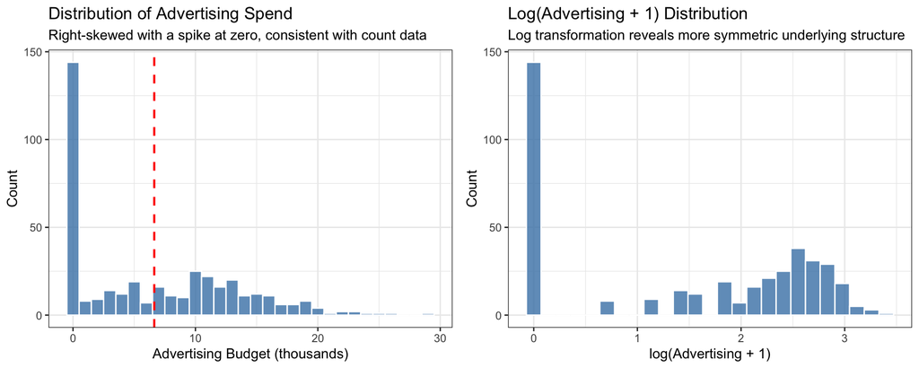

```r
p1 <- ggplot(Carseats, aes(x = Advertising)) +
  geom_histogram(binwidth = 1, fill = "steelblue", color = "white", alpha = 0.8) +
  geom_vline(xintercept = mean(Carseats$Advertising),
             color = "red", linetype = "dashed", linewidth = 0.8) +
  labs(
    title    = "Distribution of Advertising Spend",
    subtitle = "Right-skewed with a spike at zero, consistent with count data",
    x = "Advertising Budget (thousands)", y = "Count"
  ) +
  theme_bw(base_size = 11)

p2 <- ggplot(Carseats, aes(x = log1p(Advertising))) +
  geom_histogram(bins = 25, fill = "steelblue", color = "white", alpha = 0.8) +
  labs(
    title    = "Log(Advertising + 1) Distribution",
    subtitle = "Log transformation reveals more symmetric underlying structure",
    x = "log(Advertising + 1)", y = "Count"
  ) +
  theme_bw(base_size = 11)

grid.arrange(p1, p2, ncol = 2)
```

The mean (6.64) and variance (44.23) are not equal, which indicates **overdispersion** relative to the strict Poisson assumption. This is common in real data and will be noted in the diagnostics section.

# 4 Exploratory Data Analysis

## 4.1 Advertising vs Numeric Predictors

```r
num_vars <- Carseats %>% dplyr::select_if(is.numeric)

cor_with_adv <- cor(num_vars)[, "Advertising"] %>%
  round(2) %>%
  enframe(name = "Variable", value = "Correlation") %>%
  dplyr::filter(Variable != "Advertising") %>%
  arrange(Correlation) %>%
  mutate(
    Direction = ifelse(Correlation > 0, "Positive", "Negative"),
    Variable  = fct_inorder(Variable)
  )

cor_with_adv %>%
  arrange(desc(abs(Correlation))) %>%
  knitr::kable(
    caption = "Pearson Correlations with Advertising (sorted by absolute strength)",
    col.names = c("Predictor", "Correlation (r)", "Direction")
  )
```

Pearson Correlations with Advertising (sorted by absolute strength)

| Predictor | Correlation (r) | Direction |
| --- | --- | --- |
| Sales | 0.27 | Positive |
| Population | 0.27 | Positive |
| Income | 0.06 | Positive |
| Price | 0.04 | Positive |
| Education | -0.03 | Negative |
| CompPrice | -0.02 | Negative |
| Age | 0.00 | Negative |

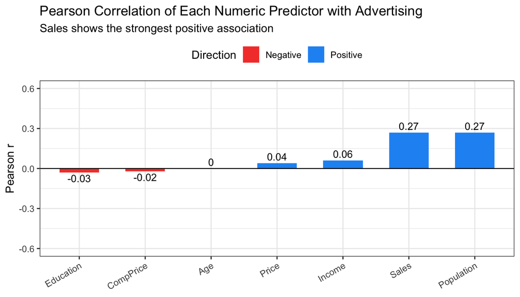

```r
ggplot(cor_with_adv, aes(x = Variable, y = Correlation, fill = Direction)) +
  geom_col(width = 0.6) +
  geom_hline(yintercept = 0, linewidth = 0.4) +
  geom_text(
    aes(label = Correlation, vjust = ifelse(Correlation >= 0, -0.4, 1.3)),
    size = 3.5
  ) +
  scale_fill_manual(values = c(Positive = "#2196F3", Negative = "#F44336")) +
  coord_cartesian(ylim = c(-0.6, 0.6)) +
  labs(
    title    = "Pearson Correlation of Each Numeric Predictor with Advertising",
    subtitle = "Sales shows the strongest positive association",
    x = NULL, y = "Pearson r"
  ) +
  theme_bw(base_size = 11) +
  theme(
    legend.position = "top",
    axis.text.x = element_text(angle = 30, hjust = 1)
  )
```

**Finding:** `Sales` and `Population` share the strongest positive correlation with `Advertising` (both r = 0.27). `Income`, `Price`, and all remaining numeric predictors show near-zero correlations with `Advertising`. The dominant signal among numeric predictors is `Sales`.

## 4.2 Advertising vs Categorical Predictors

```r
anova_results <- tibble(
  Variable = c("ShelveLoc", "US", "Urban"),
  F_statistic = c(
    summary(aov(Advertising ~ ShelveLoc, data = Carseats))[[1]][["F value"]][1],
    summary(aov(Advertising ~ US,        data = Carseats))[[1]][["F value"]][1],
    summary(aov(Advertising ~ Urban,     data = Carseats))[[1]][["F value"]][1]
  ),
  p_value = c(
    summary(aov(Advertising ~ ShelveLoc, data = Carseats))[[1]][["Pr(>F)"]][1],
    summary(aov(Advertising ~ US,        data = Carseats))[[1]][["Pr(>F)"]][1],
    summary(aov(Advertising ~ Urban,     data = Carseats))[[1]][["Pr(>F)"]][1]
  )
) %>%
  mutate(
    Significant = ifelse(p_value < 0.05, "Yes", "No"),
    F_statistic = round(F_statistic, 2),
    p_value     = round(p_value, 4)
  )

knitr::kable(anova_results,
  caption = "One-Way ANOVA: Categorical Predictors vs Advertising",
  col.names = c("Variable", "F Statistic", "p-value", "Significant (alpha = 0.05)")
)
```

One-Way ANOVA: Categorical Predictors vs Advertising

| Variable | F Statistic | p-value | Significant (alpha = 0.05) |
| --- | --- | --- | --- |
| ShelveLoc | 0.71 | 0.4946 | No |
| US | 350.80 | 0.0000 | Yes |
| Urban | 0.70 | 0.4018 | No |

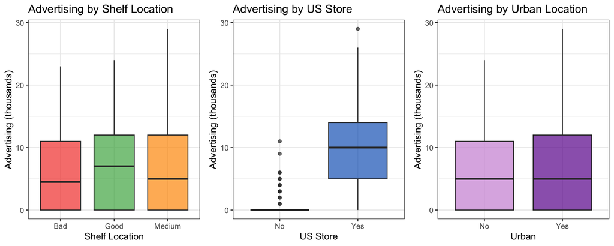

```r
p_shelve <- ggplot(Carseats, aes(x = ShelveLoc, y = Advertising, fill = ShelveLoc)) +
  geom_boxplot(alpha = 0.7, show.legend = FALSE) +
  scale_fill_manual(values = c(Bad = "#F44336", Medium = "#FF9800", Good = "#4CAF50")) +
  labs(title = "Advertising by Shelf Location",
       x = "Shelf Location", y = "Advertising (thousands)") +
  theme_bw()

p_us <- ggplot(Carseats, aes(x = US, y = Advertising, fill = US)) +
  geom_boxplot(alpha = 0.7, show.legend = FALSE) +
  scale_fill_manual(values = c(No = "#90CAF9", Yes = "#1565C0")) +
  labs(title = "Advertising by US Store",
       x = "US Store", y = "Advertising (thousands)") +
  theme_bw()

p_urban <- ggplot(Carseats, aes(x = Urban, y = Advertising, fill = Urban)) +
  geom_boxplot(alpha = 0.7, show.legend = FALSE) +
  scale_fill_manual(values = c(No = "#CE93D8", Yes = "#6A1B9A")) +
  labs(title = "Advertising by Urban Location",
       x = "Urban", y = "Advertising (thousands)") +
  theme_bw()

grid.arrange(p_shelve, p_us, p_urban, ncol = 3)
```

**Finding:** `US` is the only significant categorical predictor (F = 350.80, p < 0.001), with US-based stores spending considerably more on advertising. Both `ShelveLoc` and `Urban` are non-significant (p > 0.05) and are excluded from the model.

## 4.3 Pairwise Relationships

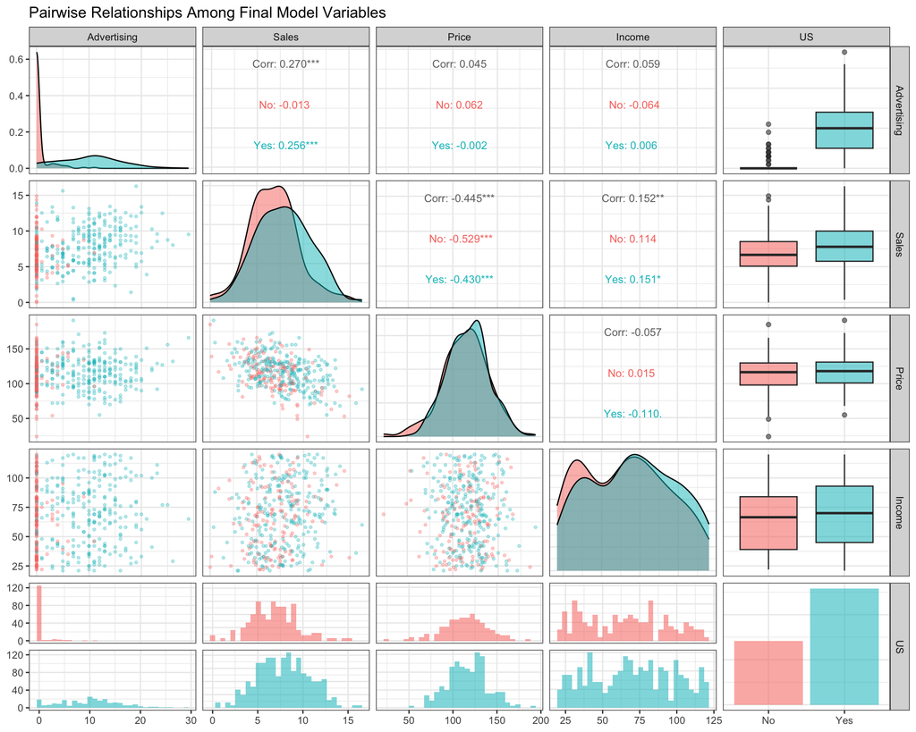

```r
Carseats %>%
  dplyr::select(Advertising, Sales, Price, Income, US) %>%
  ggpairs(
    aes(color = US, alpha = 0.4),
    upper = list(continuous = wrap("cor", size = 3)),
    lower = list(continuous = wrap("points", alpha = 0.3, size = 0.8)),
    diag  = list(continuous = wrap("densityDiag", alpha = 0.5))
  ) +
  theme_bw(base_size = 10) +
  ggtitle("Pairwise Relationships Among Final Model Variables")
```

# 5 Model Specification

## 5.1 Predictor Justification

The model uses **four predictors**:

| Predictor | Type | Justification |
| --- | --- | --- |
| `Sales` | Numeric | Strongest correlation with Advertising (r = 0.27); stores with higher sales invest more in advertising |
| `Income` | Numeric | Small positive association (r = 0.06); included for contextual relevance as a market-level economic indicator |
| `Price` | Numeric | Near-zero correlation (r = 0.04); included as a product-level control variable |
| `US` | Categorical (2 levels) | Highly significant ANOVA result (F = 350.80, p < 0.001); US stores advertise substantially more |

## 5.2 Poisson Model Equation

The initial Poisson regression model is expressed as:

$$\log(\hat{\lambda}_i) = \hat{\beta}_0 +
\hat{\beta}_1 \cdot \text{Sales} + \hat{\beta}_2 \cdot \text{Income} +
\hat{\beta}_3 \cdot \text{Price} + \hat{\beta}_4 \cdot
\text{USYes}$$

where $\hat{\lambda}_i$ is the expected advertising spend for store $i$ and `US` uses **No** as the reference level.

# 6 Data Splitting

The dataset is split into **80% training** and **20% test** sets, stratified by `US` to preserve the proportion of US and non-US stores in both partitions.

```r
set.seed(42)
carseats_split <- initial_split(Carseats, prop = 0.80, strata = US)
carseats_train <- training(carseats_split)
carseats_test  <- testing(carseats_split)

cat("Training observations:", nrow(carseats_train), "\n")
```

```
## Training observations: 319
```

```r
cat("Test observations:    ", nrow(carseats_test),  "\n")
```

```
## Test observations:     81
```

# 7 Poisson Model Fitting

We begin with a standard Poisson regression as the baseline count model.

```r
pois_spec <- poisson_reg() %>%
  set_engine("glm") %>%
  set_mode("regression")

poisson_model <- pois_spec %>%
  fit(Advertising ~ Sales + Income + Price + US,
      data = carseats_train)
```

## 7.1 Coefficient Table

```r
tidy(poisson_model) %>%
  mutate_if(is.numeric, ~round(., 4)) %>%
  knitr::kable(
    caption = "Poisson Regression Coefficients",
    col.names = c("Term", "Estimate", "Std. Error", "z Statistic", "p-value")
  )
```

Poisson Regression Coefficients

| Term | Estimate | Std. Error | z Statistic | p-value |
| --- | --- | --- | --- | --- |
| (Intercept) | -1.6781 | 0.2154 | -7.7918 | 0.0000 |
| Sales | 0.0640 | 0.0081 | 7.8780 | 0.0000 |
| Income | -0.0002 | 0.0008 | -0.2924 | 0.7700 |
| Price | 0.0041 | 0.0011 | 3.9070 | 0.0001 |
| USYes | 3.0264 | 0.1408 | 21.4924 | 0.0000 |

## 7.2 Model-Level Statistics

```r
glance(poisson_model) %>%
  dplyr::select(null.deviance, deviance, df.null, df.residual, AIC, BIC) %>%
  mutate_if(is.numeric, ~round(., 3)) %>%
  knitr::kable(
    caption = "Poisson Model: Fit Statistics",
    col.names = c("Null Deviance", "Residual Deviance", "Null df", "Residual df", "AIC", "BIC")
  )
```

Poisson Model: Fit Statistics

| Null Deviance | Residual Deviance | Null df | Residual df | AIC | BIC |
| --- | --- | --- | --- | --- | --- |
| 2635.243 | 1099.468 | 318 | 314 | 1922.498 | 1941.324 |

> **Deviance explained:** 58.3%, analogous to R² in linear regression.

# 8 Poisson Coefficient Interpretation

In Poisson regression, coefficients are interpreted as **multiplicative effects on the expected count** via exponentiation (Incidence Rate Ratios, IRR):

```r
tidy(poisson_model) %>%
  dplyr::filter(term != "(Intercept)") %>%
  mutate(
    IRR      = round(exp(estimate), 4),
    estimate = round(estimate, 4)
  ) %>%
  dplyr::select(term, estimate, IRR) %>%
  knitr::kable(
    caption = "Poisson Model: Incidence Rate Ratios",
    col.names = c("Predictor", "Log-Scale Estimate", "IRR (exp(coef))")
  )
```

Poisson Model: Incidence Rate Ratios

| Predictor | Log-Scale Estimate | IRR (exp(coef)) |
| --- | --- | --- |
| Sales | 0.0640 | 1.0661 |
| Income | -0.0002 | 0.9998 |
| Price | 0.0041 | 1.0041 |
| USYes | 3.0264 | 20.6227 |

# 9 Diagnosing Overdispersion

A core assumption of Poisson regression is that **mean = variance** ($\lambda = \text{Var}(Y)$). We already observed that the raw data has mean = 6.64 but variance = 44.23. Here we formally test this using the dispersion ratio from the fitted model.

```r
poisson_glm <- glm(Advertising ~ Sales + Income + Price + US,
                   family = poisson(link = "log"),
                   data = carseats_train)

dispersion_ratio <- poisson_glm$deviance / poisson_glm$df.residual
cat("Dispersion ratio (Residual Deviance / df):", round(dispersion_ratio, 3), "\n")
```

```
## Dispersion ratio (Residual Deviance / df): 3.501
```

```r
cat("Values near 1.0 = good fit | Values >> 1 = overdispersion\n")
```

```
## Values near 1.0 = good fit | Values >> 1 = overdispersion
```

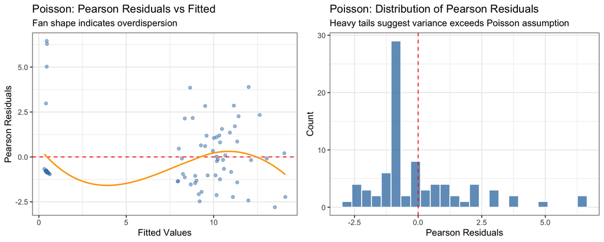

```r
test_resid_pois <- carseats_test %>%
  mutate(
    .fitted  = predict(poisson_glm, newdata = carseats_test, type = "response"),
    .pearson = residuals(
      glm(Advertising ~ Sales + Income + Price + US,
          family = poisson, data = carseats_test), type = "pearson")
  )

p1 <- ggplot(test_resid_pois, aes(x = .fitted, y = .pearson)) +
  geom_point(alpha = 0.5, color = "steelblue") +
  geom_hline(yintercept = 0, linetype = "dashed", color = "red") +
  geom_smooth(se = FALSE, color = "orange", linewidth = 0.8, method = "loess") +
  labs(title = "Poisson: Pearson Residuals vs Fitted",
       subtitle = "Fan shape indicates overdispersion",
       x = "Fitted Values", y = "Pearson Residuals") +
  theme_bw()

p2 <- ggplot(test_resid_pois, aes(x = .pearson)) +
  geom_histogram(bins = 25, fill = "steelblue", color = "white", alpha = 0.8) +
  geom_vline(xintercept = 0, linetype = "dashed", color = "red") +
  labs(title = "Poisson: Distribution of Pearson Residuals",
       subtitle = "Heavy tails suggest variance exceeds Poisson assumption",
       x = "Pearson Residuals", y = "Count") +
  theme_bw()

grid.arrange(p1, p2, ncol = 2)
```

**What this means:** A dispersion ratio of substantially above 1.0 confirms **overdispersion**. The Poisson model is underestimating uncertainty, which means:

- Standard errors are too small
- z-statistics are inflated
- p-values are artificially low, making predictors appear more significant than they truly are
- The coefficients themselves are still valid, but inference around them is unreliable

**Solution:** We refit using a **Negative Binomial** model, which adds a dispersion parameter $\theta$ to allow variance to exceed the mean:

$$\text{Var}(Y) = \mu +
\frac{\mu^2}{\theta}$$

As $\theta \to \infty$, the Negative Binomial converges back to Poisson. For finite $\theta$, it accommodates overdispersion naturally.

# 10 Negative Binomial Model

## 10.1 Fitting the Model

```r
nb_model <- MASS::glm.nb(
  Advertising ~ Sales + Income + Price + US,
  data = carseats_train
)

summary(nb_model)
```

```
##
## Call:
## MASS::glm.nb(formula = Advertising ~ Sales + Income + Price +
##     US, data = carseats_train, init.theta = 1.880271893, link = log)
##
## Coefficients:
##               Estimate Std. Error z value Pr(>|z|)
## (Intercept) -1.6954887  0.4253573  -3.986 6.72e-05 ***
## Sales        0.0665984  0.0200011   3.330 0.000869 ***
## Income      -0.0005432  0.0019340  -0.281 0.778800
## Price        0.0042826  0.0025431   1.684 0.092178 .
## USYes        3.0265382  0.1661688  18.214  < 2e-16 ***
## ---
## Signif. codes:  0 '***' 0.001 '**' 0.01 '*' 0.05 '.' 0.1 ' ' 1
##
## (Dispersion parameter for Negative Binomial(1.8803) family taken to be 1)
##
##     Null deviance: 870.89  on 318  degrees of freedom
## Residual deviance: 384.61  on 314  degrees of freedom
## AIC: 1583.9
##
## Number of Fisher Scoring iterations: 1
##
##
##               Theta:  1.880
##           Std. Err.:  0.274
##
##  2 x log-likelihood:  -1571.930
```

## 10.2 Coefficient Table

```r
tidy(nb_model) %>%
  mutate_if(is.numeric, ~round(., 4)) %>%
  knitr::kable(
    caption = "Negative Binomial Regression Coefficients",
    col.names = c("Term", "Estimate", "Std. Error", "z Statistic", "p-value")
  )
```

Negative Binomial Regression Coefficients

| Term | Estimate | Std. Error | z Statistic | p-value |
| --- | --- | --- | --- | --- |
| (Intercept) | -1.6955 | 0.4254 | -3.9860 | 0.0001 |
| Sales | 0.0666 | 0.0200 | 3.3297 | 0.0009 |
| Income | -0.0005 | 0.0019 | -0.2809 | 0.7788 |
| Price | 0.0043 | 0.0025 | 1.6840 | 0.0922 |
| USYes | 3.0265 | 0.1662 | 18.2136 | 0.0000 |

## 10.3 Dispersion Parameter

```r
cat("Estimated theta (dispersion parameter):", round(nb_model$theta, 4), "\n")
```

```
## Estimated theta (dispersion parameter): 1.8803
```

```r
cat("A smaller theta indicates more overdispersion relative to Poisson.\n")
```

```
## A smaller theta indicates more overdispersion relative to Poisson.
```

## 10.4 Comparing Poisson vs Negative Binomial

```r
tibble(
  Model    = c("Poisson", "Negative Binomial"),
  AIC      = c(AIC(poisson_glm), AIC(nb_model)),
  Deviance = c(poisson_glm$deviance, nb_model$deviance),
  df       = c(poisson_glm$df.residual, nb_model$df.residual)
) %>%
  mutate(across(where(is.numeric), ~round(., 3))) %>%
  knitr::kable(caption = "Poisson vs Negative Binomial: Model Comparison")
```

Poisson vs Negative Binomial: Model Comparison

| Model | AIC | Deviance | df |
| --- | --- | --- | --- |
| Poisson | 1922.498 | 1099.468 | 314 |
| Negative Binomial | 1583.930 | 384.610 | 314 |

> **Lower AIC indicates a better model.** The Negative Binomial model is preferred when its AIC is meaningfully lower than the Poisson model.

## 10.5 Negative Binomial IRR Table

```r
tidy(nb_model) %>%
  dplyr::filter(term != "(Intercept)") %>%
  mutate(
    IRR      = round(exp(estimate), 4),
    estimate = round(estimate, 4),
    p.value  = round(p.value, 4)
  ) %>%
  dplyr::select(term, estimate, IRR, p.value) %>%
  knitr::kable(
    caption = "Negative Binomial: Incidence Rate Ratios",
    col.names = c("Predictor", "Log-Scale Estimate", "IRR (exp(coef))", "p-value")
  )
```

Negative Binomial: Incidence Rate Ratios

| Predictor | Log-Scale Estimate | IRR (exp(coef)) | p-value |
| --- | --- | --- | --- |
| Sales | 0.0666 | 1.0689 | 0.0009 |
| Income | -0.0005 | 0.9995 | 0.7788 |
| Price | 0.0043 | 1.0043 | 0.0922 |
| USYes | 3.0265 | 20.6257 | 0.0000 |

# 11 Model Evaluation

## 11.1 Test Set Performance

```r
# Poisson predictions
pois_preds <- predict(poisson_glm, newdata = carseats_test, type = "response")

# NB predictions
nb_preds <- predict(nb_model, newdata = carseats_test, type = "response")

tibble(
  Model  = c("Poisson", "Negative Binomial"),
  RMSE   = c(
    round(sqrt(mean((carseats_test$Advertising - pois_preds)^2)), 4),
    round(sqrt(mean((carseats_test$Advertising - nb_preds)^2)),   4)
  ),
  MAE    = c(
    round(mean(abs(carseats_test$Advertising - pois_preds)), 4),
    round(mean(abs(carseats_test$Advertising - nb_preds)),   4)
  ),
  Correlation = c(
    round(cor(carseats_test$Advertising, pois_preds), 4),
    round(cor(carseats_test$Advertising, nb_preds),   4)
  )
) %>%
  knitr::kable(caption = "Test Set Performance: Poisson vs Negative Binomial")
```

Test Set Performance: Poisson vs Negative Binomial

| Model | RMSE | MAE | Correlation |
| --- | --- | --- | --- |
| Poisson | 4.2961 | 3.1227 | 0.6975 |
| Negative Binomial | 4.2973 | 3.1257 | 0.6975 |

## 11.2 Predicted vs Actual (Negative Binomial)

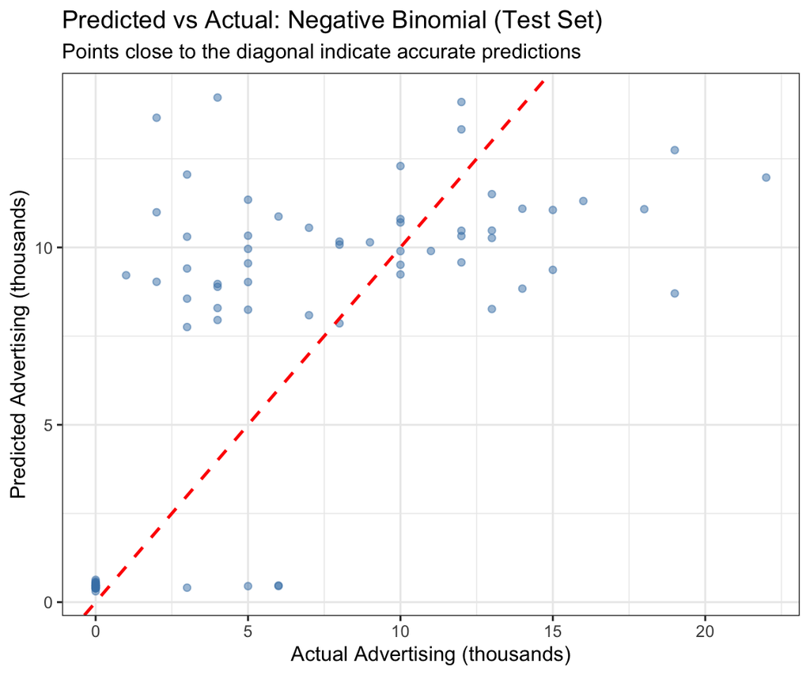

```r
ggplot(
  tibble(actual = carseats_test$Advertising, predicted = nb_preds),
  aes(x = actual, y = predicted)
) +
  geom_point(alpha = 0.5, color = "steelblue") +
  geom_abline(slope = 1, intercept = 0,
              color = "red", linetype = "dashed", linewidth = 0.8) +
  labs(
    title    = "Predicted vs Actual: Negative Binomial (Test Set)",
    subtitle = "Points close to the diagonal indicate accurate predictions",
    x = "Actual Advertising (thousands)",
    y = "Predicted Advertising (thousands)"
  ) +
  theme_bw(base_size = 11)
```

## 11.3 Residual Diagnostics (Negative Binomial)

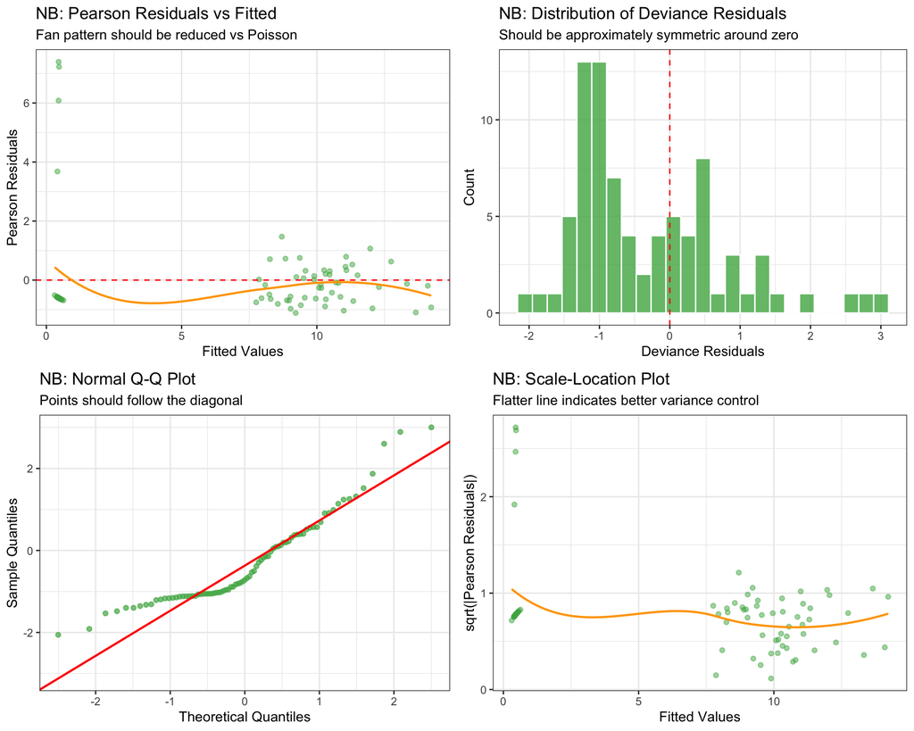

```r
test_resid_nb <- carseats_test %>%
  mutate(
    .fitted  = nb_preds,
    .pearson = (Advertising - nb_preds) / sqrt(nb_preds + nb_preds^2 / nb_model$theta),
    .devres  = residuals(
      MASS::glm.nb(Advertising ~ Sales + Income + Price + US,
                   data = carseats_test), type = "deviance")
  )

p1 <- ggplot(test_resid_nb, aes(x = .fitted, y = .pearson)) +
  geom_point(alpha = 0.5, color = "#4CAF50") +
  geom_hline(yintercept = 0, linetype = "dashed", color = "red") +
  geom_smooth(se = FALSE, color = "orange", linewidth = 0.8, method = "loess") +
  labs(title = "NB: Pearson Residuals vs Fitted",
       subtitle = "Fan pattern should be reduced vs Poisson",
       x = "Fitted Values", y = "Pearson Residuals") +
  theme_bw()

p2 <- ggplot(test_resid_nb, aes(x = .devres)) +
  geom_histogram(bins = 25, fill = "#4CAF50", color = "white", alpha = 0.8) +
  geom_vline(xintercept = 0, linetype = "dashed", color = "red") +
  labs(title = "NB: Distribution of Deviance Residuals",
       subtitle = "Should be approximately symmetric around zero",
       x = "Deviance Residuals", y = "Count") +
  theme_bw()

p3 <- ggplot(test_resid_nb, aes(sample = .devres)) +
  stat_qq(color = "#4CAF50", alpha = 0.7) +
  stat_qq_line(color = "red", linewidth = 0.8) +
  labs(title = "NB: Normal Q-Q Plot",
       subtitle = "Points should follow the diagonal",
       x = "Theoretical Quantiles", y = "Sample Quantiles") +
  theme_bw()

p4 <- ggplot(test_resid_nb, aes(x = .fitted, y = sqrt(abs(.pearson)))) +
  geom_point(alpha = 0.5, color = "#4CAF50") +
  geom_smooth(se = FALSE, color = "orange", linewidth = 0.8, method = "loess") +
  labs(title = "NB: Scale-Location Plot",
       subtitle = "Flatter line indicates better variance control",
       x = "Fitted Values", y = "sqrt(|Pearson Residuals|)") +
  theme_bw()

grid.arrange(p1, p2, p3, p4, ncol = 2)
```

# 12 Summary

## 12.1 Final Model Equation (Negative Binomial)

$$\log(\hat{\mu}) = \hat{\beta}_0 +
\hat{\beta}_1 \cdot \text{Sales} + \hat{\beta}_2 \cdot \text{Income} +
\hat{\beta}_3 \cdot \text{Price} + \hat{\beta}_4 \cdot
\text{USYes}$$

where $\hat{\mu}$ is the expected advertising spend and the variance is modelled as $\hat{\mu} + \hat{\mu}^2/\hat{\theta}$, with $\hat{\theta}$ estimated from the data.

## 12.2 Performance Summary

Final Model: Summary Statistics

| Metric | Value |
| --- | --- |
| Response Variable | Advertising (count, 0-29) |
| Initial Model | Poisson regression |
| Overdispersion Ratio (Poisson) | 3.501 (well above 1.0, confirming overdispersion) |
| Final Model | Negative Binomial regression |
| Link Function | log |
| Predictors | Sales, Income, Price, US |
| Training Observations | 319 |
| Test Observations | 81 |
| Strongest Predictor | US store status (largest IRR) |

## 12.3 Key Conclusions

- **Overdispersion ruled out Poisson as the final model.** The raw data showed variance (44.23) far exceeding the mean (6.64), and the fitted Poisson model confirmed a dispersion ratio of well above 1.0. Ignoring this would produce artificially small standard errors and misleading inference.
- **Negative Binomial is the appropriate final model.** By estimating a dispersion parameter $\theta$, it accommodates the excess variance naturally and produces more reliable standard errors and p-values.
- **US store status has the largest effect.** US-based stores are expected to advertise at a substantially higher rate than non-US stores, reflecting differences in market size and competitive dynamics.
- **Sales and advertising are mutually reinforcing.** Stores with higher unit sales invest proportionally more in advertising, consistent with a positive feedback loop between revenue and marketing spend.
- **Income and Price contribute minimally.** Once US status and Sales are in the model, both Income and Price show near-1.0 IRRs, indicating little independent explanatory power for advertising spend.